# The Olympics

MIS 545 Project

Ryan Straight

2020-08-29

# Introduction

The Olympics has become a financial juggernaut from the viewpoint of both the hosting country and the value of being a medalist. In 2016, the Rio Olymipcs cost $13.1 billion US dollars (7.23 billion reals) to host. This included “a subway line, a doping laboratory, a renovated port and cleanup of pouted Guanabara Bay.”

[Rio Olympics cost $13.1 billion](https://olympics.nbcsports.com/2017/06/14/rio-olympics-cost-13-billion/)

The value of *gold* is more than the value of the medal, of course. Countries reward their medalists depending on which medal they bring home and these rewards vary drastically from country to country. Singapore, for example, rewards gold medalists with $1 million USD while Canada pays a comparatively paltry $15,000 USD. Advertising sales during the Rio Olympics in 2016 totaled $1.2 billion USD.

[Here’s how much Olympic athletes earn in 12 different countries](https://www.cnbc.com/2018/02/23/heres-how-much-olympic-athletes-earn-in-12-different-countries.html)

[NBC says it has topped $1 billion in national ad sales for 2020 Summer Olympics](https://www.cnbc.com/2019/12/10/nbc-says-it-topped-1b-in-national-ad-sales-for-2020-summer-olympics.html)

Needless to say, it behooves interested parties to be able to predict just who, when, and where medalists will crop up, whether this is in an effort to determine if the 12-year-old male gymnast in Sweden is likely to be a 16-year-old gold medalist in four years or if this or that country is worth scouting in for talent given their past medal winnings.

# The Chosen Data

The purpose of this project is to apply a variety of classification and predictive methodologies to a chosen data set for the purposes of demonstrating knowledge and skills developed throughout the semester. The dataset chosen for this project is [120 years of Olympic history: athletes and results](https://www.kaggle.com/heesoo37/120-years-of-olympic-history-athletes-and-results) This particular dataset was chosen for a variety of reasons:

Described by the creator as “basic bio data on athletes and medal results from Athens 1896 to Rio 2016.”

- It is relatively large, coming in 271,116 rows when loaded raw.
- There is a variety of variable types to work with, providing a range of options when it comes to different classification and preditive tests.
- It affords a certain level of approachability and familiarity by virtue of its content; after all, we all know Olympic medalists.

The purpose of this study, then, is to examine the particulars of the Olympic historical record and attempt to identify trends and make predictions thereby. Three possibilities for this data in this context come to mind:

1. What trends are apparent in nations’ medal totals?
2. What demographics contribute to medaling?
3. Can we predict a medal based on a collection of an athlete’s demographics?

## A Description of the Data

The data originates in a [Kaggle.com dataset](https://www.kaggle.com/heesoo37/120-years-of-olympic-history-athletes-and-results?select=athlete_events.csv) provided by [Randi Griffin](https://www.kaggle.com/heesoo37). According to Griffin,

> This is a historical dataset on the modern Olympic Games, including all the Games from Athens 1896 to Rio 2016 [scraped from] www.sports-reference.com in May 2018…. Note that the Winter and Summer Games were held in the same year up until 1992. After that, they staggered them such that Winter Games occur on a four year cycle starting with 1994, then Summer in 1996, then Winter in 1998, and so on. A common mistake people make when analyzing this data is to assume that the Summer and Winter Games have always been staggered.

The dataset is delivered in two files: `athlete_events.csv` and `noc_regions.csv`. The descriptions are provided in the data source.

| File | Variable | Data type | Data format | Description |
| --- | --- | --- | --- | --- |
| athlete_events.csv |  |  |  |  |
|  | ID | ind | int | Unique number for each athlete |
|  | Name | ind | chr | Athlete’s name |
|  | Sex | dep | chr | M or F |
|  | Age | ind | int | Integer |
|  | Height | ind | int | In centimeters |
|  | Weight | ind | num | In kilograms |
|  | Team | ind | chr | Team name |
|  | NOC | ind | chr | National Olympic Committee 3 letter code |
|  | Games | ind | chr | Year and season |
|  | Year | ind | int | Integer |
|  | Season | ind | chr | Summer or Winter |
|  | City | ind | chr | City |
|  | Sport | ind | chr | Sport |
|  | Event | ind | chr | Event |
|  | Medal | dep | chr | Gold, Silver, Bronze, or `NA` |
| noc_regions.csv |  |  |  |  |
|  | NOC | ind | chr | National Olympic Committee 3 letter code |
|  | region | ind | chr | Country name (matches with regions in `map_data("world")` |
|  | notes | ind | chr | Notes |

# Data Pre-Processing

Fortunately, Griffin’s scraping techniques prove tidy and in need of very little cleaning, all things considered. The entirety of the loading and tidying is as follows:

```r
# tidy up the titles
athlete_events <- athlete_events %>% clean_names()
noc_regions <- noc_regions %>% clean_names()

# Join up athlete_events and noc_regions to get a nice country name
olympics <- as_tibble(athlete_events %>% left_join(noc_regions, by = "noc"))

# Switch to factors
olympics <- olympics %>%
  mutate(across(c("sex", "team", "noc", "games", "year", "sport", "city",
    "region", "season"), factor))

# Replace NAs in "medal" with "None"
olympics$medal <- olympics$medal %>%
  replace_na("none") %>%
  as_factor()

# There are way too many sports and a few only happened a couple times.
# Pare those down to the top 50, naming the rest "Other."
olympics$sport <- olympics$sport %>%
  fct_lump_n(n = 51)
```

With this we can now explore the data a bit easier. Note that each row in this dataset is for an *athlete*.

Summary table of relevant data

|  | age | height | weight | year | medal |
| --- | --- | --- | --- | --- | --- |
|  | Min. :10.00 | Min. :127.0 | Min. : 25.0 | 1992 : 16413 | none :231333 |
|  | 1st Qu.:21.00 | 1st Qu.:168.0 | 1st Qu.: 60.0 | 1988 : 14676 | Gold : 13372 |
|  | Median :24.00 | Median :175.0 | Median : 70.0 | 2000 : 13821 | Bronze: 13295 |
|  | Mean :25.56 | Mean :175.3 | Mean : 70.7 | 1996 : 13780 | Silver: 13116 |
|  | 3rd Qu.:28.00 | 3rd Qu.:183.0 | 3rd Qu.: 79.0 | 2016 : 13688 | NA |
|  | Max. :97.00 | Max. :226.0 | Max. :214.0 | 2008 : 13602 | NA |
|  | NA’s :9474 | NA’s :60171 | NA’s :62875 | (Other):185136 | NA |

Follows is a look at the structure of the numerical data to verify data formats are as expected.

| variable | class | first_values |
| --- | --- | --- |
| id | double | 1, 2, 3, 4, 5, 5 |
| name | character | A Dijiang, A Lamusi, Gunnar Nielsen Aaby, Edgar Lindenau Aabye, Christine Jacoba Aaftink, Christine Jacoba Aaftink |
| sex | integer | M, M, M, M, F, F |
| age | double | 24, 23, 24, 34, 21, 21 |
| height | double | 180, 170, NA, NA, 185, 185 |
| weight | double | 80, 60, NA, NA, 82, 82 |
| team | integer | China, China, Denmark, Denmark/Sweden, Netherlands, Netherlands |
| noc | integer | CHN, CHN, DEN, DEN, NED, NED |
| games | integer | 1992 Summer, 2012 Summer, 1920 Summer, 1900 Summer, 1988 Winter, 1988 Winter |
| year | integer | 1992, 2012, 1920, 1900, 1988, 1988 |
| season | integer | Summer, Summer, Summer, Summer, Winter, Winter |
| city | integer | Barcelona, London, Antwerpen, Paris, Calgary, Calgary |
| sport | integer | Basketball, Judo, Football, Other, Speed Skating, Speed Skating |
| event | character | Basketball Men’s Basketball, Judo Men’s Extra-Lightweight, Football Men’s Football, Tug-Of-War Men’s Tug-Of-War, Speed Skating Women’s 500 metres, Speed Skating Women’s 1,000 metres |
| medal | integer | none, none, none, Gold, none, none |
| region | integer | China, China, Denmark, Denmark, Netherlands, Netherlands |
| notes | character | NA, NA, NA, NA, NA, NA |
| decade | integer | 1990s, 2010s, 1920s, 1900s, 1980s, 1980s |

# Descriptive Analysis

Let’s begin to actually dig into the data.

Data summary

| Name | Piped data |
| --- | --- |
| Number of rows | 271116 |
| Number of columns | 16 |
| _______________________ |  |
| Column type frequency: |  |
| character | 2 |
| factor | 11 |
| numeric | 3 |
| ________________________ |  |
| Group variables | None |

**Variable type: character**

| skim_variable | n_missing | complete_rate | min | max | empty | n_unique | whitespace |
| --- | --- | --- | --- | --- | --- | --- | --- |
| name | 0 | 1 | 2 | 108 | 0 | 134731 | 0 |
| event | 0 | 1 | 15 | 85 | 0 | 765 | 0 |

**Variable type: factor**

| skim_variable | n_missing | complete_rate | ordered | n_unique | top_counts |
| --- | --- | --- | --- | --- | --- |
| sex | 0 | 1 | FALSE | 2 | M: 196594, F: 74522 |
| team | 0 | 1 | FALSE | 1184 | Uni: 17847, Fra: 11988, Gre: 11404, Ita: 10260 |
| noc | 0 | 1 | FALSE | 230 | USA: 18853, FRA: 12758, GBR: 12256, ITA: 10715 |
| games | 0 | 1 | FALSE | 51 | 200: 13821, 199: 13780, 201: 13688, 200: 13602 |
| year | 0 | 1 | FALSE | 35 | 199: 16413, 198: 14676, 200: 13821, 199: 13780 |
| season | 0 | 1 | FALSE | 2 | Sum: 222552, Win: 48564 |
| city | 0 | 1 | FALSE | 42 | Lon: 22426, Ath: 15556, Syd: 13821, Atl: 13780 |
| sport | 0 | 1 | FALSE | 52 | Ath: 38624, Gym: 26707, Swi: 23195, Sho: 11448 |
| medal | 0 | 1 | FALSE | 4 | non: 231333, Gol: 13372, Bro: 13295, Sil: 13116 |
| region | 370 | 1 | FALSE | 205 | USA: 18853, Ger: 15883, Fra: 12758, UK: 12256 |
| decade | 0 | 1 | FALSE | 13 | 200: 49357, 199: 36958, 201: 35901, 198: 35201 |

**Variable type: numeric**

| skim_variable | n_missing | complete_rate | mean | sd | p0 | p25 | p50 | p75 | p100 | hist |
| --- | --- | --- | --- | --- | --- | --- | --- | --- | --- | --- |
| age | 9474 | 0.97 | 25.56 | 6.39 | 10 | 21 | 24 | 28 | 97 | ▇▃▁▁▁ |
| height | 60171 | 0.78 | 175.34 | 10.52 | 127 | 168 | 175 | 183 | 226 | ▁▂▇▂▁ |
| weight | 62875 | 0.77 | 70.70 | 14.35 | 25 | 60 | 70 | 79 | 214 | ▃▇▁▁▁ |

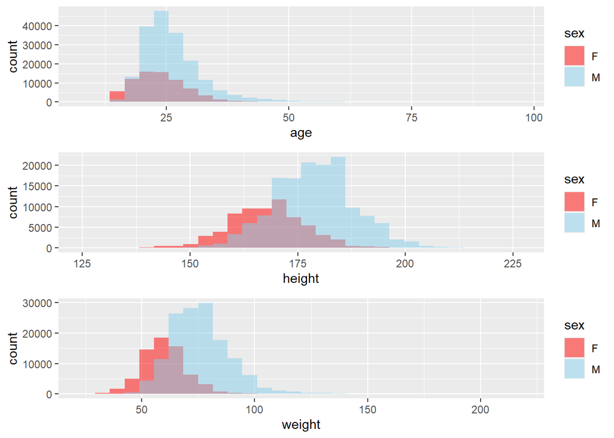

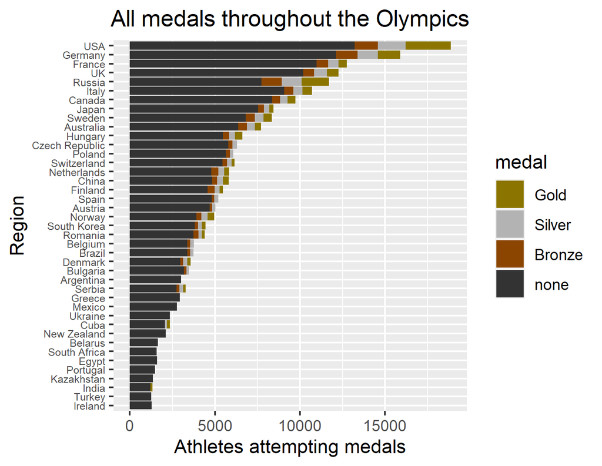

## Kmeans Clustering

```
##        age.V1             weight.V1           height.V1      sex
##  Min.   :-2.276806   Min.   :-3.185275   Min.   :-4.595631   F: 66711
##  1st Qu.:-0.712732   1st Qu.:-0.745914   1st Qu.:-0.697723   M:139454
##  Median :-0.243510   Median :-0.048954   Median :-0.032226
##  Mean   :-0.078421   Mean   :-0.000980   Mean   : 0.003135
##  3rd Qu.: 0.382119   3rd Qu.: 0.578310   3rd Qu.: 0.728341
##  Max.   : 7.107636   Max.   : 9.987274   Max.   : 4.816391
```

Based on the elbrow graph below we can see the optimum number of clusters is actually 3.

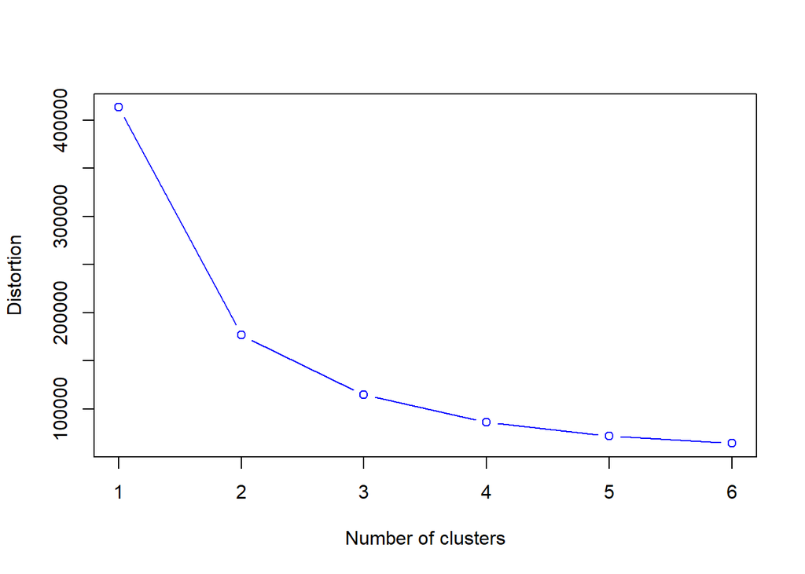

Now let’s look at the clustered data.

```
## List of 9
##  $ cluster     : int [1:206165] 1 3 2 2 2 2 2 2 1 1 ...
##  $ centers     : num [1:3, 1:2] 0.0583 1.3551 -0.9651 0.1824 1.2584 ...
##   ..- attr(*, "dimnames")=List of 2
##   .. ..$ : chr [1:3] "1" "2" "3"
##   .. ..$ : chr [1:2] "weight" "height"
##  $ totss       : num 413192
##  $ withinss    : num [1:3] 34353 43853 36569
##  $ tot.withinss: num 114775
##  $ betweenss   : num 298417
##  $ size        : int [1:3] 92165 45017 68983
##  $ iter        : int 3
##  $ ifault      : int 0
##  - attr(*, "class")= chr "kmeans"
```

By comparing the clustering animation with a scatterplot of `sex`, we can see there is a good deal of overlap between the clusters. (Note that while there appear to be *considerable* numbers of outliers, this does not actually imply errors as the ranges are legitimately that wide. There was a 10-year-old boy participating in the Olympics in 1896 and he even won bronze) So, while there are actually only two sexes reported in the data but three clusters identified, this tells us that height and weight of athletes is not necessarily a good match for sex, at least not without breaking the data down more between regions, decades, or events.

[Greece’s Dimitrios Loundras is the youngest known Olympic medallist.](https://www.insidethegames.biz/articles/1017305/greece-s-dimitrios-loundras-is-the-youngest-known-olympic-medallist)

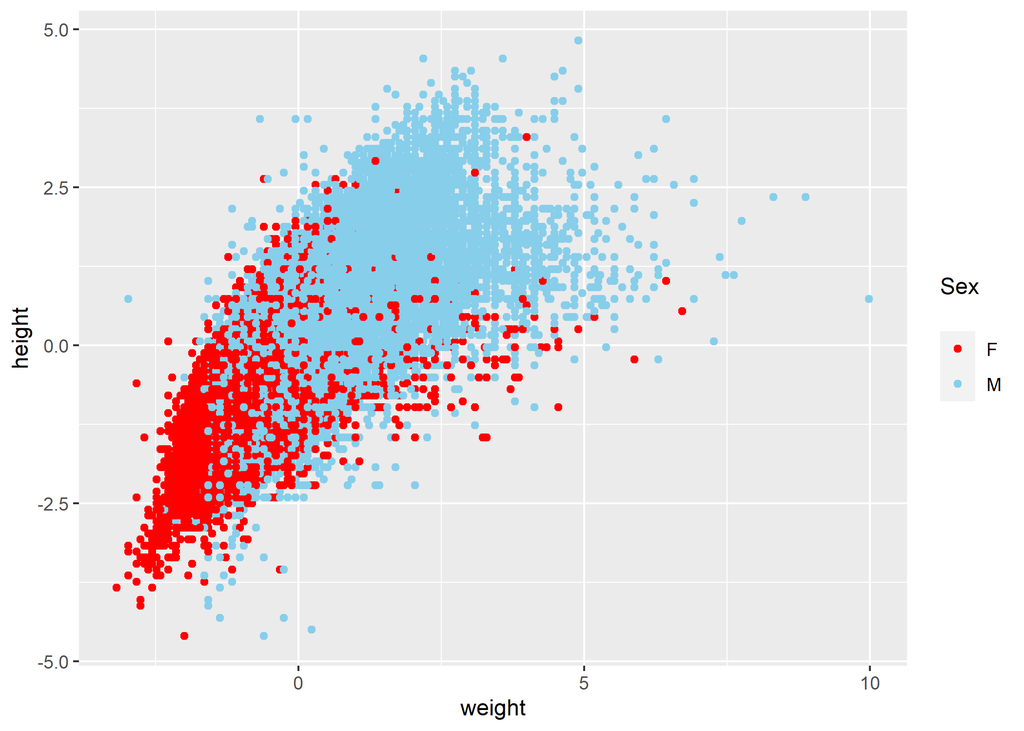

Scatterplot of weight and height for comparison to kmeans clustering.

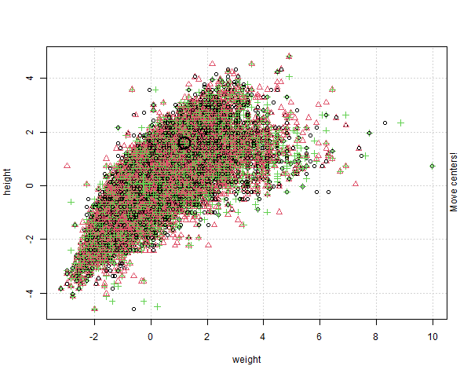

Of course, the efficiency and actual usefulness of the *k-means* clustering method presumes there is the relationship between the data. It also requires early exploration of the structure of the data, for example looking at the elbow plot above, to determine what is likely the optimal number of clusters. To avoid randomness being introduced, best practices are to use the R function `set.seed()` to ensure the same results each time.

# Prediction

Given the size and nature of the data, as introduced at the beginning of this report, it is possible to predict which demographic or biological attributes predict medal winnings in athletes.

## Decision Trees

```
##
## Call:
## C5.0.default(x = train[, medal_predictors], y = train$sex)
##
##
## C5.0 [Release 2.07 GPL Edition]      Sat Aug 29 11:47:42 2020
## -------------------------------
##
## Class specified by attribute `outcome'
##
## Read 19355 cases (4 attributes) from undefined.data
##
## Decision tree:
##
## age > 18: M (18244.6/4707.5)
## age <= 18:
## :...region in {Australia,Canada,Germany,Hungary,Italy,Russia,Sweden,UK,
##     :          USA}: F (1057.1/332.7)
##     region = France: M (53.4/8.1)
##
##
## Evaluation on training data (19355 cases):
##
##      Decision Tree
##    ----------------
##    Size      Errors
##
##       3 5038(26.0%)   <<
##
##
##     (a)   (b)    <-classified as
##    ----  ----
##     724  4716    (a): class F
##     322 13593    (b): class M
##
##
##  Attribute usage:
##
##   98.61% age
##    7.05% region
##
##
## Time: 0.0 secs
```

And the plotted decision tree is as follows:

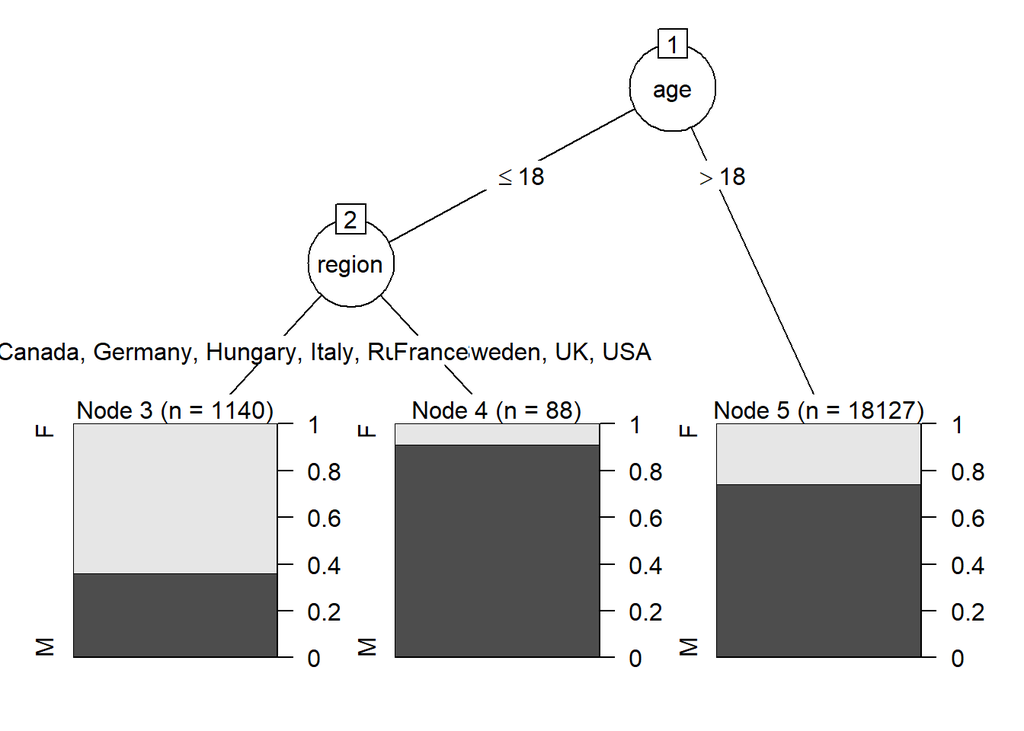

The gender makeup has changed considerably over the past half century. Let’s look at that now. Examining the factors that go into medal winning while paying special attention to whether the athlete is an adult or a minor.

```
##
## Call:
## C5.0.default(x = trainB[, medal_predictorsB], y = trainB$medal)
##
##
## C5.0 [Release 2.07 GPL Edition]      Sat Aug 29 11:47:42 2020
## -------------------------------
##
## Class specified by attribute `outcome'
##
## Read 13190 cases (4 attributes) from undefined.data
##
## Decision tree:
##
## region = USA: Gold (3130/1693)
## region in {Australia,Canada,France,Germany,Hungary,Italy,Russia,Sweden,UK}:
## :...region in {Australia,France,Sweden}: Bronze (2786/1786)
##     region in {Canada,Germany,Hungary,Italy,Russia,UK}:
##     :...adult = Minor: Silver (118.6/70.5)
##         adult = Adult:
##         :...sex = M: Gold (4865.5/3006)
##             sex = F:
##             :...region in {Canada,Germany,Hungary,Italy,
##                 :          Russia}: Gold (2033/1287)
##                 region = UK: Bronze (256.9/145)
##
##
## Evaluation on training data (13190 cases):
##
##      Decision Tree
##    ----------------
##    Size      Errors
##
##       6 7988(60.6%)   <<
##
##
##     (a)   (b)   (c)    <-classified as
##    ----  ----  ----
##    4043   867    34    (a): class Gold
##    2952  1112    35    (b): class Bronze
##    3036  1064    47    (c): class Silver
##
##
##  Attribute usage:
##
##  100.00% region
##   54.27% sex
##   53.93% adult
##
##
## Time: 0.0 secs
```

[figure not shown]

# Neural Networks

There are, of course, other ways of predicting attributes. One such way that has garnered renewed interest over recent years is the *neural network*, made possible here by the `neuralnet` package.

## Determining sex

By feeding the network with age, height, weight, and year (during which the athlete participated), we can determine the sex of the athlete. As shown by the figure below and the confusion matrix in the margins, this method of prediction is 85% accurate.

```
## Confusion Matrix and Statistics
##
##
##       0   1
##   0 415 142
##   1  91 941
##
##                Accuracy : 0.8534
##                  95% CI : (0.835, 0.8704)
##     No Information Rate : 0.6816
##     P-Value [Acc > NIR] : < 2.2e-16
##
##                   Kappa : 0.671
##
##  Mcnemar's Test P-Value : 0.001054
##
##             Sensitivity : 0.8202
##             Specificity : 0.8689
##          Pos Pred Value : 0.7451
##          Neg Pred Value : 0.9118
##              Prevalence : 0.3184
##          Detection Rate : 0.2612
##    Detection Prevalence : 0.3505
##       Balanced Accuracy : 0.8445
##
##        'Positive' Class : 0
##
```

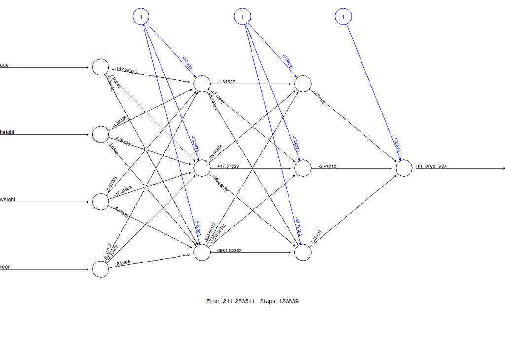

## Determining medal

To determine a gold medal winner we can use various other demographics and qualities of the atheletes, like sex, age, height, weight, and the year they participated. This method is only 59% accurate, suggesting we need more information and possibly a different method of determining just what is important when considering gold medal earnings in the modern olympics.

```
## Confusion Matrix and Statistics
##
##
##        0    1
##   0 2204  167
##   1 1420  169
##
##                Accuracy : 0.5992
##                  95% CI : (0.5838, 0.6146)
##     No Information Rate : 0.9152
##     P-Value [Acc > NIR] : 1
##
##                   Kappa : 0.0413
##
##  Mcnemar's Test P-Value : <2e-16
##
##             Sensitivity : 0.6082
##             Specificity : 0.5030
##          Pos Pred Value : 0.9296
##          Neg Pred Value : 0.1064
##              Prevalence : 0.9152
##          Detection Rate : 0.5566
##    Detection Prevalence : 0.5987
##       Balanced Accuracy : 0.5556
##
##        'Positive' Class : 0
##
```

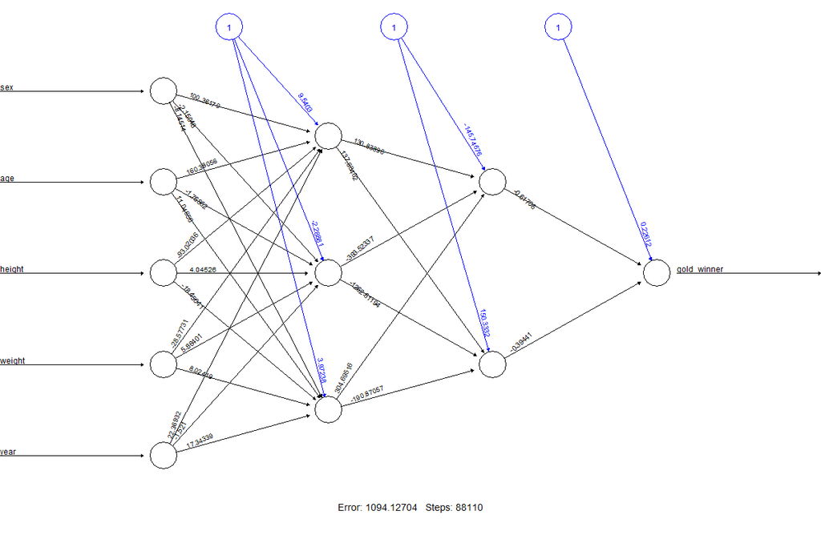

One pitfall with this particular model is the fact that so many more athletes have attempted medaling and failed than have actually won medals (this is not surprising, of course). Given our research questions and business purpose for this report, we suggest, as the previous model, breaking down the data into time series and based on regions, perhaps even events. Again, this is beyond the scope of this report.

# Conclusion

The modern Olympics are a fascinating–if somewhat problematic–phenomenon that produces some truly interesting data upon which we can draw conslusion and make predictions. Given our business purposes and research questions (trends in nations’ medal totals, demographics contribute to medaling, and predicting a medal based on an athlete’s demographics), this data is mostly sufficient in providing that necessary for the chosen models (k-means clustering, decision trees, and neural networks).

Trends in nations’ medal winnings are fairly clear: those nations that send more athletes tend to win more models. This isn’t precisely surprising but it does draw attention to the fact that medals, especially gold medals, do not simply appear out of nowhere; they are worked for against tremendous competition. If we are interested in dealing with gold medal winners, we should clearly be inclined to work with a definite list of countries, as demonstrated in the descriptive statistics above.

Which leads us to the fascinating neural networks’ prediction abilities. It seems it’s much easier to predict the sex of an athlete (consider this along side the previous decision trees) than it is to predict whether they will win a medal. This is, it would appear given the confusion matrices above, due to the sheer number of non-gold-medal-winning attempts compared to the relatively small number of gold medals. Again, further and deeper analyses may be able to mitigate this and provide an even clearer predictive model regarding just who will win a gold next time, where they come from, and how old they will be.